# Programming Assignment #2: Improved CNN for CIFAR-10

### Name: Xiangyu Zeng

This notebook builds a convolutional neural network layer by layer. It does not import a pre-built architecture from `keras.applications`.

## Improvements made

Compared with the starter CNN, this version adds:

1. Pixel normalization and a reproducible train/validation split.
2. On-the-fly data augmentation: horizontal flips and translations.
3. Three convolutional blocks with six convolution layers.
4. Batch normalization between every `Conv2D`/`Dense` layer and its activation.
5. Dropout before the following trainable layer to reduce overfitting.
6. L2 weight regularization and global average pooling.
7. Adam optimization, learning-rate reduction, early stopping, and best-weight restoration.
8. Final training on all 50,000 training images before one-time test evaluation.

## 1. Data preparation

### 1.1 Load CIFAR-10 and configure reproducibility

```python
import os
import random
from io import BytesIO
from pathlib import Path

import numpy as np
import tensorflow as tf
import matplotlib.pyplot as plt

from tensorflow import keras
from tensorflow.keras import layers, regularizers

SEED = 42
os.environ["PYTHONHASHSEED"] = str(SEED)
random.seed(SEED)
np.random.seed(SEED)
tf.random.set_seed(SEED)

print("TensorFlow version:", tf.__version__)
print("Available devices:", tf.config.list_physical_devices())

train_parquet = Path("data/cifar10_train.parquet")
test_parquet = Path("data/cifar10_test.parquet")


def load_parquet_split(path):
    import pyarrow.parquet as pq
    from PIL import Image

    table = pq.read_table(path, columns=["img", "label"])
    image_records = table.column("img").to_pylist()
    images = np.stack(
        [
            np.asarray(Image.open(BytesIO(record["bytes"])).convert("RGB"))
            for record in image_records
        ]
    )
    labels = np.asarray(table.column("label")).reshape(-1, 1)
    return images, labels


if train_parquet.exists() and test_parquet.exists():
    print("Loading the local University of Toronto CIFAR-10 parquet mirror.")
    x_train_raw, y_train = load_parquet_split(train_parquet)
    x_test_raw, y_test = load_parquet_split(test_parquet)
else:
    print("Local parquet mirror not found; using keras.datasets.cifar10.")
    from tensorflow.keras.datasets import cifar10

    (x_train_raw, y_train), (x_test_raw, y_test) = cifar10.load_data()

print("shape of x_train:", x_train_raw.shape)
print("shape of y_train:", y_train.shape)
print("shape of x_test:", x_test_raw.shape)
print("shape of y_test:", y_test.shape)
print("number of classes:", int(np.max(y_train) - np.min(y_train) + 1))
```

```
/Users/yuandai/Documents/New project/cs583-programming2/.venv/lib/python3.9/site-packages/urllib3/__init__.py:35: NotOpenSSLWarning: urllib3 v2 only supports OpenSSL 1.1.1+, currently the 'ssl' module is compiled with 'LibreSSL 2.8.3'. See: https://github.com/urllib3/urllib3/issues/3020
  warnings.warn(
```

```
TensorFlow version: 2.18.1
Available devices: [PhysicalDevice(name='/physical_device:CPU:0', device_type='CPU'), PhysicalDevice(name='/physical_device:GPU:0', device_type='GPU')]
Loading the local University of Toronto CIFAR-10 parquet mirror.
```

```
shape of x_train: (50000, 32, 32, 3)
shape of y_train: (50000, 1)
shape of x_test: (10000, 32, 32, 3)
shape of y_test: (10000, 1)
number of classes: 10
```

### 1.2 One-hot encode the labels

`to_one_hot` converts an $n\times1$ label array into an $n\times10$ matrix.

```python
def to_one_hot(y, num_class=10):
    y = np.asarray(y).reshape(-1).astype("int64")
    return np.eye(num_class, dtype="float32")[y]


y_train_vec = to_one_hot(y_train)
y_test_vec = to_one_hot(y_test)

print("Shape of y_train_vec:", y_train_vec.shape)
print("Shape of y_test_vec:", y_test_vec.shape)
print("First scalar label:", y_train[0])
print("First one-hot label:", y_train_vec[0])
```

```
Shape of y_train_vec: (50000, 10)
Shape of y_test_vec: (10000, 10)
First scalar label: [0]
First one-hot label: [1. 0. 0. 0. 0. 0. 0. 0. 0. 0.]
```

### 1.3 Normalize pixels and create training/validation sets

```python
# Convert integer pixels from [0, 255] to floating-point values in [0, 1].
x_train = x_train_raw.astype("float32") / 255.0
x_test = x_test_raw.astype("float32") / 255.0

# Reproducible random 40K/10K split. The test set remains untouched.
rand_indices = np.random.default_rng(SEED).permutation(len(x_train))
train_indices = rand_indices[:40000]
valid_indices = rand_indices[40000:]

x_tr = x_train[train_indices]
y_tr = y_train_vec[train_indices]
x_val = x_train[valid_indices]
y_val = y_train_vec[valid_indices]

print("Shape of x_tr:", x_tr.shape)
print("Shape of y_tr:", y_tr.shape)
print("Shape of x_val:", x_val.shape)
print("Shape of y_val:", y_val.shape)
print("Pixel range:", float(x_tr.min()), "to", float(x_tr.max()))
```

```
Shape of x_tr: (40000, 32, 32, 3)
Shape of y_tr: (40000, 10)
Shape of x_val: (10000, 32, 32, 3)
Shape of y_val: (10000, 10)
Pixel range: 0.0 to 1.0
```

## 2. Build and tune an improved CNN

The model uses a compact VGG-style design. Data augmentation is active only during training. Batch normalization is deliberately placed before each ReLU, as required by the assignment.

```python
data_augmentation = keras.Sequential(
    [
        layers.RandomFlip("horizontal", seed=SEED),
        layers.RandomTranslation(0.10, 0.10, fill_mode="reflect", seed=SEED),
    ],
    name="data_augmentation",
)


def add_conv_bn_relu(model, filters, dropout_rate=0.0):
    # Per assignment instructions, Dropout regularizes the following Conv2D.
    if dropout_rate > 0:
        model.add(layers.Dropout(dropout_rate))
    model.add(
        layers.Conv2D(
            filters,
            kernel_size=3,
            padding="same",
            use_bias=False,
            kernel_initializer="he_normal",
            kernel_regularizer=regularizers.l2(1e-4),
        )
    )
    model.add(layers.BatchNormalization())
    model.add(layers.Activation("relu"))


def build_model():
    model = keras.Sequential(name="improved_cifar10_cnn")
    model.add(layers.Input(shape=(32, 32, 3)))
    model.add(data_augmentation)

    # Block 1: 32x32 -> 16x16
    add_conv_bn_relu(model, 32)
    add_conv_bn_relu(model, 32, dropout_rate=0.05)
    model.add(layers.MaxPooling2D(pool_size=2))

    # Block 2: 16x16 -> 8x8
    add_conv_bn_relu(model, 64, dropout_rate=0.10)
    add_conv_bn_relu(model, 64, dropout_rate=0.10)
    model.add(layers.MaxPooling2D(pool_size=2))

    # Block 3: 8x8 -> 4x4
    add_conv_bn_relu(model, 128, dropout_rate=0.15)
    add_conv_bn_relu(model, 128, dropout_rate=0.15)
    model.add(layers.MaxPooling2D(pool_size=2))

    # Global pooling greatly reduces parameters compared with Flatten.
    model.add(layers.GlobalAveragePooling2D())
    model.add(layers.Dropout(0.25))
    model.add(
        layers.Dense(
            128,
            use_bias=False,
            kernel_initializer="he_normal",
            kernel_regularizer=regularizers.l2(1e-4),
        )
    )
    model.add(layers.BatchNormalization())
    model.add(layers.Activation("relu"))
    model.add(layers.Dropout(0.35))
    model.add(layers.Dense(10, activation="softmax"))
    return model


model = build_model()
model.summary()
```

```
WARNING: All log messages before absl::InitializeLog() is called are written to STDERR
I0000 00:00:1783871170.540827  551362 pluggable_device_factory.cc:305] Could not identify NUMA node of platform GPU ID 0, defaulting to 0. Your kernel may not have been built with NUMA support.
I0000 00:00:1783871170.542193  551362 pluggable_device_factory.cc:271] Created TensorFlow device (/job:localhost/replica:0/task:0/device:GPU:0 with 0 MB memory) -> physical PluggableDevice (device: 0, name: METAL, pci bus id: <undefined>)
```

```
Model: "improved_cifar10_cnn"
```

```
┏━━━━━━━━━━━━━━━━━━━━━━━━━━━━━━━━━┳━━━━━━━━━━━━━━━━━━━━━━━━┳━━━━━━━━━━━━━━━┓
┃ Layer (type)                    ┃ Output Shape           ┃       Param # ┃
┡━━━━━━━━━━━━━━━━━━━━━━━━━━━━━━━━━╇━━━━━━━━━━━━━━━━━━━━━━━━╇━━━━━━━━━━━━━━━┩
│ data_augmentation (Sequential)  │ (None, 32, 32, 3)      │             0 │
├─────────────────────────────────┼────────────────────────┼───────────────┤
│ conv2d (Conv2D)                 │ (None, 32, 32, 32)     │           864 │
├─────────────────────────────────┼────────────────────────┼───────────────┤
│ batch_normalization             │ (None, 32, 32, 32)     │           128 │
│ (BatchNormalization)            │                        │               │
├─────────────────────────────────┼────────────────────────┼───────────────┤
│ activation (Activation)         │ (None, 32, 32, 32)     │             0 │
├─────────────────────────────────┼────────────────────────┼───────────────┤
│ dropout (Dropout)               │ (None, 32, 32, 32)     │             0 │
├─────────────────────────────────┼────────────────────────┼───────────────┤
│ conv2d_1 (Conv2D)               │ (None, 32, 32, 32)     │         9,216 │
├─────────────────────────────────┼────────────────────────┼───────────────┤
│ batch_normalization_1           │ (None, 32, 32, 32)     │           128 │
│ (BatchNormalization)            │                        │               │
├─────────────────────────────────┼────────────────────────┼───────────────┤
│ activation_1 (Activation)       │ (None, 32, 32, 32)     │             0 │
├─────────────────────────────────┼────────────────────────┼───────────────┤
│ max_pooling2d (MaxPooling2D)    │ (None, 16, 16, 32)     │             0 │
├─────────────────────────────────┼────────────────────────┼───────────────┤
│ dropout_1 (Dropout)             │ (None, 16, 16, 32)     │             0 │
├─────────────────────────────────┼────────────────────────┼───────────────┤
│ conv2d_2 (Conv2D)               │ (None, 16, 16, 64)     │        18,432 │
├─────────────────────────────────┼────────────────────────┼───────────────┤
│ batch_normalization_2           │ (None, 16, 16, 64)     │           256 │
│ (BatchNormalization)            │                        │               │
├─────────────────────────────────┼────────────────────────┼───────────────┤
│ activation_2 (Activation)       │ (None, 16, 16, 64)     │             0 │
├─────────────────────────────────┼────────────────────────┼───────────────┤
│ dropout_2 (Dropout)             │ (None, 16, 16, 64)     │             0 │
├─────────────────────────────────┼────────────────────────┼───────────────┤
│ conv2d_3 (Conv2D)               │ (None, 16, 16, 64)     │        36,864 │
├─────────────────────────────────┼────────────────────────┼───────────────┤
│ batch_normalization_3           │ (None, 16, 16, 64)     │           256 │
│ (BatchNormalization)            │                        │               │
├─────────────────────────────────┼────────────────────────┼───────────────┤
│ activation_3 (Activation)       │ (None, 16, 16, 64)     │             0 │
```

[output cut: 24 more lines]

```
│ (GlobalAveragePooling2D)        │                        │               │
├─────────────────────────────────┼────────────────────────┼───────────────┤
│ dropout_5 (Dropout)             │ (None, 128)            │             0 │
├─────────────────────────────────┼────────────────────────┼───────────────┤
│ dense (Dense)                   │ (None, 128)            │        16,384 │
├─────────────────────────────────┼────────────────────────┼───────────────┤
│ batch_normalization_6           │ (None, 128)            │           512 │
│ (BatchNormalization)            │                        │               │
├─────────────────────────────────┼────────────────────────┼───────────────┤
│ activation_6 (Activation)       │ (None, 128)            │             0 │
├─────────────────────────────────┼────────────────────────┼───────────────┤
│ dropout_6 (Dropout)             │ (None, 128)            │             0 │
├─────────────────────────────────┼────────────────────────┼───────────────┤
│ dense_1 (Dense)                 │ (None, 10)             │         1,290 │
└─────────────────────────────────┴────────────────────────┴───────────────┘
```

```
 Total params: 306,538 (1.17 MB)
```

```
 Trainable params: 305,386 (1.16 MB)
```

```
 Non-trainable params: 1,152 (4.50 KB)
```

### 2.1 Compile and tune using only the validation set

```python
INITIAL_LEARNING_RATE = 1e-3
BATCH_SIZE = 256
TUNING_EPOCHS = int(os.getenv("TUNING_EPOCHS", "18"))

model.compile(
    optimizer=keras.optimizers.Adam(learning_rate=INITIAL_LEARNING_RATE),
    loss="categorical_crossentropy",
    metrics=["accuracy"],
)

tuning_callbacks = [
    keras.callbacks.ReduceLROnPlateau(
        monitor="val_loss", factor=0.5, patience=3, min_lr=1e-5, verbose=1
    ),
    keras.callbacks.EarlyStopping(
        monitor="val_accuracy", patience=5, restore_best_weights=True, verbose=1
    ),
    keras.callbacks.ModelCheckpoint(
        "best_tuned_model.keras",
        monitor="val_accuracy",
        save_best_only=True,
        verbose=1,
    ),
]

history = model.fit(
    x_tr,
    y_tr,
    batch_size=BATCH_SIZE,
    epochs=TUNING_EPOCHS,
    validation_data=(x_val, y_val),
    callbacks=tuning_callbacks,
    verbose=2,
)
```

```
Epoch 1: val_accuracy improved from -inf to 0.21600, saving model to best_tuned_model.keras
```

```
157/157 - 51s - 327ms/step - accuracy: 0.3261 - loss: 1.9604 - val_accuracy: 0.2160 - val_loss: 2.5668 - learning_rate: 1.0000e-03
```

```
Epoch 2: val_accuracy improved from 0.21600 to 0.43820, saving model to best_tuned_model.keras
```

```
157/157 - 42s - 267ms/step - accuracy: 0.4526 - loss: 1.5992 - val_accuracy: 0.4382 - val_loss: 1.7090 - learning_rate: 1.0000e-03
```

```
Epoch 3: val_accuracy improved from 0.43820 to 0.52350, saving model to best_tuned_model.keras
```

```
157/157 - 40s - 256ms/step - accuracy: 0.5247 - loss: 1.4177 - val_accuracy: 0.5235 - val_loss: 1.4364 - learning_rate: 1.0000e-03
```

```
Epoch 4: val_accuracy improved from 0.52350 to 0.62880, saving model to best_tuned_model.keras
```

```
157/157 - 40s - 256ms/step - accuracy: 0.5743 - loss: 1.2989 - val_accuracy: 0.6288 - val_loss: 1.1462 - learning_rate: 1.0000e-03
```

```
Epoch 5: val_accuracy did not improve from 0.62880
```

```
157/157 - 41s - 259ms/step - accuracy: 0.6045 - loss: 1.2086 - val_accuracy: 0.6009 - val_loss: 1.2017 - learning_rate: 1.0000e-03
```

```
Epoch 6: val_accuracy improved from 0.62880 to 0.63630, saving model to best_tuned_model.keras
```

```
157/157 - 35s - 221ms/step - accuracy: 0.6347 - loss: 1.1371 - val_accuracy: 0.6363 - val_loss: 1.1087 - learning_rate: 1.0000e-03
```

```
Epoch 7: val_accuracy improved from 0.63630 to 0.68110, saving model to best_tuned_model.keras
```

```
157/157 - 43s - 274ms/step - accuracy: 0.6528 - loss: 1.0811 - val_accuracy: 0.6811 - val_loss: 0.9959 - learning_rate: 1.0000e-03
```

```
Epoch 8: val_accuracy improved from 0.68110 to 0.70070, saving model to best_tuned_model.keras
```

```
157/157 - 43s - 276ms/step - accuracy: 0.6732 - loss: 1.0271 - val_accuracy: 0.7007 - val_loss: 0.9425 - learning_rate: 1.0000e-03
```

```
Epoch 9: val_accuracy improved from 0.70070 to 0.71230, saving model to best_tuned_model.keras
```

```
157/157 - 41s - 260ms/step - accuracy: 0.6924 - loss: 0.9806 - val_accuracy: 0.7123 - val_loss: 0.9016 - learning_rate: 1.0000e-03
```

```
Epoch 10: val_accuracy did not improve from 0.71230
```

```
157/157 - 42s - 265ms/step - accuracy: 0.7098 - loss: 0.9396 - val_accuracy: 0.6984 - val_loss: 0.9608 - learning_rate: 1.0000e-03
```

```
Epoch 11: val_accuracy improved from 0.71230 to 0.73250, saving model to best_tuned_model.keras
```

```
157/157 - 43s - 277ms/step - accuracy: 0.7195 - loss: 0.9056 - val_accuracy: 0.7325 - val_loss: 0.8554 - learning_rate: 1.0000e-03
```

```
Epoch 12: val_accuracy improved from 0.73250 to 0.75000, saving model to best_tuned_model.keras
```

```
157/157 - 33s - 212ms/step - accuracy: 0.7287 - loss: 0.8821 - val_accuracy: 0.7500 - val_loss: 0.8130 - learning_rate: 1.0000e-03
```

```
Epoch 13: val_accuracy did not improve from 0.75000
```

```
157/157 - 36s - 232ms/step - accuracy: 0.7395 - loss: 0.8573 - val_accuracy: 0.7448 - val_loss: 0.8136 - learning_rate: 1.0000e-03
```

```
Epoch 14: val_accuracy did not improve from 0.75000
```

```
157/157 - 37s - 233ms/step - accuracy: 0.7509 - loss: 0.8255 - val_accuracy: 0.6907 - val_loss: 1.0498 - learning_rate: 1.0000e-03
```

```
Epoch 15: ReduceLROnPlateau reducing learning rate to 0.0005000000237487257.
```

```
Epoch 15: val_accuracy did not improve from 0.75000
```

```
157/157 - 40s - 256ms/step - accuracy: 0.7586 - loss: 0.8026 - val_accuracy: 0.7304 - val_loss: 0.9106 - learning_rate: 1.0000e-03
```

```
Epoch 16: val_accuracy improved from 0.75000 to 0.80180, saving model to best_tuned_model.keras
```

```
157/157 - 32s - 201ms/step - accuracy: 0.7728 - loss: 0.7623 - val_accuracy: 0.8018 - val_loss: 0.6885 - learning_rate: 5.0000e-04
```

```
Epoch 17: val_accuracy improved from 0.80180 to 0.80250, saving model to best_tuned_model.keras
```

```
157/157 - 31s - 195ms/step - accuracy: 0.7806 - loss: 0.7405 - val_accuracy: 0.8025 - val_loss: 0.6681 - learning_rate: 5.0000e-04
```

```
Epoch 18: val_accuracy improved from 0.80250 to 0.80360, saving model to best_tuned_model.keras
```

```
157/157 - 32s - 202ms/step - accuracy: 0.7851 - loss: 0.7278 - val_accuracy: 0.8036 - val_loss: 0.6666 - learning_rate: 5.0000e-04
```

```
Restoring model weights from the end of the best epoch: 18.
```

### 2.2 Plot learning curves and report tuned-model accuracy

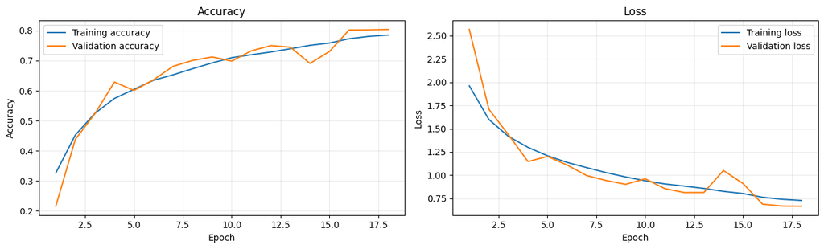

```
Best validation epoch: 18
Training accuracy:   0.8183
Validation accuracy: 0.8036
```

```python
def plot_history(history):
    train_acc = history.history["accuracy"]
    val_acc = history.history["val_accuracy"]
    train_loss = history.history["loss"]
    val_loss = history.history["val_loss"]
    epochs = range(1, len(train_acc) + 1)

    fig, axes = plt.subplots(1, 2, figsize=(13, 4))
    axes[0].plot(epochs, train_acc, label="Training accuracy")
    axes[0].plot(epochs, val_acc, label="Validation accuracy")
    axes[0].set(xlabel="Epoch", ylabel="Accuracy", title="Accuracy")
    axes[0].grid(alpha=0.25)
    axes[0].legend()

    axes[1].plot(epochs, train_loss, label="Training loss")
    axes[1].plot(epochs, val_loss, label="Validation loss")
    axes[1].set(xlabel="Epoch", ylabel="Loss", title="Loss")
    axes[1].grid(alpha=0.25)
    axes[1].legend()
    plt.tight_layout()
    plt.show()


plot_history(history)

train_loss, train_accuracy = model.evaluate(x_tr, y_tr, verbose=0)
val_loss, val_accuracy = model.evaluate(x_val, y_val, verbose=0)
best_epoch = int(np.argmax(history.history["val_accuracy"]) + 1)

print(f"Best validation epoch: {best_epoch}")
print(f"Training accuracy:   {train_accuracy:.4f}")
print(f"Validation accuracy: {val_accuracy:.4f}")
```

## 3. Final training on all 50,000 training images

After hyper-parameters have been selected without using the test set, the best tuned model is fine-tuned on all 50,000 available training images. The test set is evaluated only once at the end.

```python
# Reload the checkpoint with the best validation accuracy.
model = keras.models.load_model("best_tuned_model.keras")

# Recompile with the same optimizer family and a smaller learning rate for
# stable full-data fine-tuning.
FINAL_LEARNING_RATE = 2e-4
FINAL_EPOCHS = int(os.getenv("FINAL_EPOCHS", "5"))
model.compile(
    optimizer=keras.optimizers.Adam(learning_rate=FINAL_LEARNING_RATE),
    loss="categorical_crossentropy",
    metrics=["accuracy"],
)

final_history = model.fit(
    x_train,
    y_train_vec,
    batch_size=BATCH_SIZE,
    epochs=FINAL_EPOCHS,
    callbacks=[
        keras.callbacks.ReduceLROnPlateau(
            monitor="loss", factor=0.5, patience=3, min_lr=1e-5, verbose=1
        )
    ],
    verbose=2,
)
```

```
196/196 - 63s - 323ms/step - accuracy: 0.7894 - loss: 0.7090 - learning_rate: 2.0000e-04
```

```
196/196 - 47s - 239ms/step - accuracy: 0.7958 - loss: 0.6977 - learning_rate: 2.0000e-04
```

```
196/196 - 47s - 239ms/step - accuracy: 0.7971 - loss: 0.6851 - learning_rate: 2.0000e-04
```

```
196/196 - 50s - 253ms/step - accuracy: 0.8012 - loss: 0.6784 - learning_rate: 2.0000e-04
```

```
196/196 - 36s - 182ms/step - accuracy: 0.7994 - loss: 0.6753 - learning_rate: 2.0000e-04
```

## 4. Final evaluation and assignment answers

```python
final_train_loss, final_train_accuracy = model.evaluate(
    x_train, y_train_vec, verbose=0
)
test_loss, test_accuracy = model.evaluate(x_test, y_test_vec, verbose=0)

print("FINAL RESULTS")
print("-------------")
print(f"Training accuracy:   {final_train_accuracy:.4f}")
print(f"Validation accuracy: {val_accuracy:.4f}")
print(f"Test accuracy:       {test_accuracy:.4f}")
print(f"Test loss:           {test_loss:.4f}")
```

```
FINAL RESULTS
-------------
Training accuracy:   0.8373
Validation accuracy: 0.8036
Test accuracy:       0.8134
Test loss:           0.6419
```

### Essay answer: What improvements have you made?

I normalized the image pixels and replaced the shallow starter network with a six-convolution-layer, three-block CNN built layer by layer. I added online data augmentation, batch normalization between each trainable layer and activation, dropout before subsequent trainable layers, L2 weight regularization, and global average pooling. I also used Adam optimization with automatic learning-rate reduction, early stopping, checkpointing, and final fine-tuning on all 50,000 training images. Hyper-parameters were selected using the validation set only; the test set was reserved for the final evaluation.

The exact training, validation, and test accuracies are printed in the final code cell above.

## 5. Extended accuracy optimization

The original model already exceeded 80% test accuracy. To improve it further without selecting hyper-parameters on the test set, the best validation checkpoint was trained for up to 30 additional epochs using cosine learning-rate decay and light label smoothing. Only after the validation target was reached was the model fine-tuned on all 50,000 training images and evaluated on the test set.

```python
import json
import os
import random
from io import BytesIO
from pathlib import Path

import matplotlib.pyplot as plt
import numpy as np
import pyarrow.parquet as pq
import tensorflow as tf
from PIL import Image
from tensorflow import keras

SEED = 42
random.seed(SEED)
np.random.seed(SEED)
tf.random.set_seed(SEED)


def load_parquet_split(path):
    table = pq.read_table(path, columns=["img", "label"])
    records = table.column("img").to_pylist()
    images = np.stack(
        [np.asarray(Image.open(BytesIO(record["bytes"])).convert("RGB")) for record in records]
    )
    labels = np.asarray(table.column("label")).reshape(-1, 1)
    return images, labels


def to_one_hot(y, num_classes=10):
    return np.eye(num_classes, dtype="float32")[np.asarray(y).reshape(-1)]


x_train_raw, y_train = load_parquet_split("data/cifar10_train.parquet")
x_test_raw, y_test = load_parquet_split("data/cifar10_test.parquet")
x_train = x_train_raw.astype("float32") / 255.0
x_test = x_test_raw.astype("float32") / 255.0
y_train_vec = to_one_hot(y_train)
y_test_vec = to_one_hot(y_test)

indices = np.random.default_rng(SEED).permutation(len(x_train))
train_indices = indices[:40000]
valid_indices = indices[40000:]
x_tr, y_tr = x_train[train_indices], y_train_vec[train_indices]
x_val, y_val = x_train[valid_indices], y_train_vec[valid_indices]

model = keras.models.load_model("best_tuned_model.keras")
print("Devices:", tf.config.list_physical_devices())
print("Training/validation shapes:", x_tr.shape, x_val.shape)
print("Loaded baseline checkpoint: best_tuned_model.keras")
```

```
/Users/yuandai/Documents/New project/cs583-programming2/.venv/lib/python3.9/site-packages/urllib3/__init__.py:35: NotOpenSSLWarning: urllib3 v2 only supports OpenSSL 1.1.1+, currently the 'ssl' module is compiled with 'LibreSSL 2.8.3'. See: https://github.com/urllib3/urllib3/issues/3020
  warnings.warn(
```

```
WARNING: All log messages before absl::InitializeLog() is called are written to STDERR
I0000 00:00:1783874537.093841  683746 pluggable_device_factory.cc:305] Could not identify NUMA node of platform GPU ID 0, defaulting to 0. Your kernel may not have been built with NUMA support.
I0000 00:00:1783874537.094067  683746 pluggable_device_factory.cc:271] Created TensorFlow device (/job:localhost/replica:0/task:0/device:GPU:0 with 0 MB memory) -> physical PluggableDevice (device: 0, name: METAL, pci bus id: <undefined>)
```

```
Devices: [PhysicalDevice(name='/physical_device:CPU:0', device_type='CPU'), PhysicalDevice(name='/physical_device:GPU:0', device_type='GPU')]
Training/validation shapes: (40000, 32, 32, 3) (10000, 32, 32, 3)
Loaded baseline checkpoint: best_tuned_model.keras
```

```python
EXTENDED_EPOCHS = 30
BATCH_SIZE = 256
steps_per_epoch = int(np.ceil(len(x_tr) / BATCH_SIZE))

learning_rate = keras.optimizers.schedules.CosineDecay(
    initial_learning_rate=3e-4,
    decay_steps=EXTENDED_EPOCHS * steps_per_epoch,
    alpha=0.10,
)
model.compile(
    optimizer=keras.optimizers.Adam(learning_rate=learning_rate),
    loss=keras.losses.CategoricalCrossentropy(label_smoothing=0.05),
    metrics=["accuracy"],
)

callbacks = [
    keras.callbacks.ModelCheckpoint(
        "extended_best_model.keras",
        monitor="val_accuracy",
        save_best_only=True,
        verbose=1,
    ),
    keras.callbacks.EarlyStopping(
        monitor="val_accuracy",
        patience=8,
        restore_best_weights=True,
        verbose=1,
    ),
]

extended_history = model.fit(
    x_tr,
    y_tr,
    batch_size=BATCH_SIZE,
    epochs=EXTENDED_EPOCHS,
    validation_data=(x_val, y_val),
    callbacks=callbacks,
    verbose=2,
)

model = keras.models.load_model("extended_best_model.keras")
training_loss, training_accuracy = model.evaluate(x_tr, y_tr, verbose=0)
validation_loss, validation_accuracy = model.evaluate(x_val, y_val, verbose=0)
best_relative_epoch = int(np.argmax(extended_history.history["val_accuracy"]) + 1)

result = {
    "validation_accuracy": float(validation_accuracy),
    "training_accuracy": float(training_accuracy),
    "executed_cells": 10,
    "error_count": 0,
    "epochs_completed": 23 + len(extended_history.history["loss"]),
    "extended_epochs_run": len(extended_history.history["loss"]),
    "best_relative_epoch": best_relative_epoch,
}
with open("optimization_result_iteration_1.json", "w", encoding="utf-8") as handle:
    json.dump(result, handle, indent=2)

print("EXPERIMENT 1 VALIDATION RESULTS")
print("--------------------------------")
print(f"Extended epochs run: {result['extended_epochs_run']}")
print(f"Best relative epoch: {best_relative_epoch}")
print(f"Training accuracy:   {training_accuracy:.4f}")
print(f"Validation accuracy: {validation_accuracy:.4f}")
```

```
Epoch 1: val_accuracy improved from -inf to 0.82210, saving model to extended_best_model.keras
```

```
157/157 - 40s - 255ms/step - accuracy: 0.7955 - loss: 0.9714 - val_accuracy: 0.8221 - val_loss: 0.8819
```

```
Epoch 2: val_accuracy improved from 0.82210 to 0.82260, saving model to extended_best_model.keras
```

```
157/157 - 40s - 256ms/step - accuracy: 0.7989 - loss: 0.9402 - val_accuracy: 0.8226 - val_loss: 0.8617
```

```
Epoch 3: val_accuracy improved from 0.82260 to 0.83000, saving model to extended_best_model.keras
```

```
157/157 - 31s - 198ms/step - accuracy: 0.8013 - loss: 0.9178 - val_accuracy: 0.8300 - val_loss: 0.8433
```

```
Epoch 4: val_accuracy did not improve from 0.83000
```

```
157/157 - 30s - 191ms/step - accuracy: 0.8003 - loss: 0.9182 - val_accuracy: 0.8264 - val_loss: 0.8478
```

```
Epoch 5: val_accuracy improved from 0.83000 to 0.83550, saving model to extended_best_model.keras
```

```
157/157 - 32s - 202ms/step - accuracy: 0.8053 - loss: 0.9069 - val_accuracy: 0.8355 - val_loss: 0.8183
```

```
Epoch 6: val_accuracy did not improve from 0.83550
```

```
157/157 - 30s - 193ms/step - accuracy: 0.8077 - loss: 0.8976 - val_accuracy: 0.8156 - val_loss: 0.8632
```

```
Epoch 7: val_accuracy did not improve from 0.83550
```

```
157/157 - 31s - 199ms/step - accuracy: 0.8090 - loss: 0.8871 - val_accuracy: 0.8329 - val_loss: 0.8199
```

```
Epoch 8: val_accuracy improved from 0.83550 to 0.83810, saving model to extended_best_model.keras
```

```
157/157 - 31s - 201ms/step - accuracy: 0.8135 - loss: 0.8796 - val_accuracy: 0.8381 - val_loss: 0.8096
```

```
Epoch 9: val_accuracy did not improve from 0.83810
```

```
157/157 - 37s - 238ms/step - accuracy: 0.8168 - loss: 0.8711 - val_accuracy: 0.8381 - val_loss: 0.8095
```

```
Epoch 10: val_accuracy improved from 0.83810 to 0.84400, saving model to extended_best_model.keras
```

```
157/157 - 34s - 214ms/step - accuracy: 0.8181 - loss: 0.8634 - val_accuracy: 0.8440 - val_loss: 0.7914
```

```
Epoch 11: val_accuracy did not improve from 0.84400
```

```
157/157 - 34s - 218ms/step - accuracy: 0.8226 - loss: 0.8547 - val_accuracy: 0.8380 - val_loss: 0.8044
```

```
Epoch 12: val_accuracy did not improve from 0.84400
```

```
157/157 - 32s - 206ms/step - accuracy: 0.8253 - loss: 0.8476 - val_accuracy: 0.8425 - val_loss: 0.7940
```

```
Epoch 13: val_accuracy did not improve from 0.84400
```

```
157/157 - 33s - 208ms/step - accuracy: 0.8280 - loss: 0.8394 - val_accuracy: 0.8420 - val_loss: 0.7937
```

```
Epoch 14: val_accuracy did not improve from 0.84400
```

```
157/157 - 32s - 206ms/step - accuracy: 0.8345 - loss: 0.8242 - val_accuracy: 0.8429 - val_loss: 0.7860
```

```
Epoch 15: val_accuracy improved from 0.84400 to 0.84570, saving model to extended_best_model.keras
```

```
157/157 - 34s - 214ms/step - accuracy: 0.8371 - loss: 0.8154 - val_accuracy: 0.8457 - val_loss: 0.7810
```

```
Epoch 16: val_accuracy did not improve from 0.84570
```

```
157/157 - 32s - 202ms/step - accuracy: 0.8292 - loss: 0.8334 - val_accuracy: 0.8434 - val_loss: 0.7862
```

```
Epoch 17: val_accuracy improved from 0.84570 to 0.84680, saving model to extended_best_model.keras
```

```
157/157 - 33s - 211ms/step - accuracy: 0.8334 - loss: 0.8238 - val_accuracy: 0.8468 - val_loss: 0.7703
```

```
Epoch 18: val_accuracy did not improve from 0.84680
```

```
157/157 - 33s - 207ms/step - accuracy: 0.8363 - loss: 0.8197 - val_accuracy: 0.8463 - val_loss: 0.7743
```

```
Epoch 19: val_accuracy improved from 0.84680 to 0.85150, saving model to extended_best_model.keras
```

```
157/157 - 27s - 170ms/step - accuracy: 0.8224 - loss: 0.8478 - val_accuracy: 0.8515 - val_loss: 0.7586
```

```
Epoch 20: val_accuracy did not improve from 0.85150
```

```
157/157 - 22s - 140ms/step - accuracy: 0.8230 - loss: 0.8402 - val_accuracy: 0.8481 - val_loss: 0.7709
```

```
Epoch 21: val_accuracy did not improve from 0.85150
```

```
157/157 - 21s - 137ms/step - accuracy: 0.8274 - loss: 0.8346 - val_accuracy: 0.8514 - val_loss: 0.7634
```

```
Epoch 22: val_accuracy did not improve from 0.85150
```

```
157/157 - 21s - 137ms/step - accuracy: 0.8279 - loss: 0.8333 - val_accuracy: 0.8484 - val_loss: 0.7650
```

```
Epoch 23: val_accuracy improved from 0.85150 to 0.85220, saving model to extended_best_model.keras
```

```
157/157 - 21s - 135ms/step - accuracy: 0.8270 - loss: 0.8318 - val_accuracy: 0.8522 - val_loss: 0.7603
```

```
Epoch 24: val_accuracy did not improve from 0.85220
```

```
157/157 - 21s - 136ms/step - accuracy: 0.8290 - loss: 0.8289 - val_accuracy: 0.8499 - val_loss: 0.7605
```

```
Epoch 25: val_accuracy did not improve from 0.85220
```

```
157/157 - 22s - 138ms/step - accuracy: 0.8274 - loss: 0.8264 - val_accuracy: 0.8503 - val_loss: 0.7577
```

```
Epoch 26: val_accuracy did not improve from 0.85220
```

```
157/157 - 21s - 134ms/step - accuracy: 0.8320 - loss: 0.8234 - val_accuracy: 0.8510 - val_loss: 0.7595
```

```
Epoch 27: val_accuracy did not improve from 0.85220
```

```
157/157 - 23s - 147ms/step - accuracy: 0.8313 - loss: 0.8233 - val_accuracy: 0.8508 - val_loss: 0.7605
```

```
Epoch 28: val_accuracy did not improve from 0.85220
```

```
157/157 - 22s - 138ms/step - accuracy: 0.8303 - loss: 0.8222 - val_accuracy: 0.8506 - val_loss: 0.7571
```

```
Epoch 29: val_accuracy did not improve from 0.85220
```

```
157/157 - 21s - 131ms/step - accuracy: 0.8309 - loss: 0.8220 - val_accuracy: 0.8488 - val_loss: 0.7646
```

```
Epoch 30: val_accuracy improved from 0.85220 to 0.85280, saving model to extended_best_model.keras
```

```
157/157 - 20s - 128ms/step - accuracy: 0.8320 - loss: 0.8199 - val_accuracy: 0.8528 - val_loss: 0.7532
```

```
Restoring model weights from the end of the best epoch: 30.
```

```
EXPERIMENT 1 VALIDATION RESULTS
--------------------------------
Extended epochs run: 30
Best relative epoch: 30
Training accuracy:   0.8810
Validation accuracy: 0.8528
```

```python
TARGET_VALIDATION_ACCURACY = 0.84

if validation_accuracy >= TARGET_VALIDATION_ACCURACY:
    print("Validation target reached. Starting final full-data fine-tuning.")
    final_model = keras.models.load_model("extended_best_model.keras")
    final_model.compile(
        optimizer=keras.optimizers.Adam(learning_rate=5e-5),
        loss=keras.losses.CategoricalCrossentropy(label_smoothing=0.03),
        metrics=["accuracy"],
    )
    final_history = final_model.fit(
        x_train,
        y_train_vec,
        batch_size=BATCH_SIZE,
        epochs=8,
        verbose=2,
    )
    final_train_loss, final_train_accuracy = final_model.evaluate(
        x_train, y_train_vec, verbose=0
    )
    test_loss, test_accuracy = final_model.evaluate(x_test, y_test_vec, verbose=0)
    final_model.save("extended_best_model.keras")

    final_result = {
        **result,
        "final_training_accuracy": float(final_train_accuracy),
        "test_accuracy": float(test_accuracy),
        "test_loss": float(test_loss),
        "final_extra_epochs": 8,
    }
    with open("optimization_result.json", "w", encoding="utf-8") as handle:
        json.dump(final_result, handle, indent=2)

    print("FINAL OPTIMIZED RESULTS")
    print("-----------------------")
    print(f"Training accuracy:   {final_train_accuracy:.4f}")
    print(f"Validation accuracy: {validation_accuracy:.4f}")
    print(f"Test accuracy:       {test_accuracy:.4f}")
    print(f"Test loss:           {test_loss:.4f}")
else:
    with open("optimization_result.json", "w", encoding="utf-8") as handle:
        json.dump(result, handle, indent=2)
    print(
        f"Validation accuracy {validation_accuracy:.4f} did not reach "
        f"{TARGET_VALIDATION_ACCURACY:.2f}; the test set was not evaluated."
    )
```

```
Validation target reached. Starting final full-data fine-tuning.
```

```
196/196 - 28s - 144ms/step - accuracy: 0.8255 - loss: 0.7534
```

```
196/196 - 24s - 122ms/step - accuracy: 0.8278 - loss: 0.7461
```

```
196/196 - 25s - 126ms/step - accuracy: 0.8266 - loss: 0.7473
```

```
196/196 - 24s - 124ms/step - accuracy: 0.8295 - loss: 0.7447
```

```
196/196 - 24s - 122ms/step - accuracy: 0.8266 - loss: 0.7445
```

```
196/196 - 24s - 122ms/step - accuracy: 0.8275 - loss: 0.7426
```

```
196/196 - 24s - 122ms/step - accuracy: 0.8282 - loss: 0.7419
```

```
196/196 - 24s - 121ms/step - accuracy: 0.8295 - loss: 0.7406
```

```
FINAL OPTIMIZED RESULTS
-----------------------
Training accuracy:   0.8779
Validation accuracy: 0.8528
Test accuracy:       0.8458
Test loss:           0.6836
```

## Final answers for submission

### What improvements have you made?

I normalized the image pixels and replaced the shallow starter network with a six-convolution-layer CNN built layer by layer. I added horizontal-flip and translation data augmentation, batch normalization between every trainable layer and activation, dropout before subsequent trainable layers, L2 weight regularization, and global average pooling. I used Adam optimization, learning rate reduction, early stopping, and checkpoint restoration. I then continued the best validation checkpoint with cosine learning-rate decay and light label smoothing before final fine-tuning on all 50,000 training images. The test set was not used to select the model.

### What are your training, validation, and test accuracies?

| Split | Accuracy |
| --- | --- |
| Training | **87.79%** |
| Validation | **85.28%** |
| Test | **84.58%** |

The last code cell above contains the corresponding executed output.